# NASA Asteroid Risk Analysis in R

A Probability & Inferential Modeling Project

Team Members: Person 1 (EDA & Distributions), Person 2 (Hypothesis Testing), Person 3 (Regression Models)

2026-10-18

# Project Overview & Objective

This project investigates orbital encounter data from NASA’s Near-Earth Object (NEO) program. Our goals are: 1. Summarize and visualize intrinsic brightness, velocity, and close approach metrics. 2. Fit continuous and discrete theoretical probability distributions (Normal, Poisson, Binomial). 3. Conduct parametric and non-parametric hypothesis tests across hazard classes and orbit parameters. 4. Model asteroid diameter and relative velocity using Simple and Multiple Linear Regression.

# Data Ingestion & Preprocessing

```r
# Ingest processed RDS, raw CSV, or generate mock fallback
if (file.exists("../data/processed/neo_clean.rds")) {
  neo_data <- readRDS("../data/processed/neo_clean.rds")
} else if (file.exists("../data/raw/neo.csv")) {
  neo_data <- read.csv("../data/raw/neo.csv")
  neo_data <- na.omit(neo_data)
} else {
  # Fallback simulation if no file is present
  set.seed(42)
  n <- 1000
  neo_data <- data.frame(
    absolute_magnitude = rnorm(n, mean = 22.5, sd = 2.8),
    estimated_diameter_min = runif(n, 0.05, 0.8),
    relative_velocity = rnorm(n, mean = 48000, sd = 15000),
    miss_distance = runif(n, 5e6, 7e7),
    is_potentially_hazardous = sample(c(TRUE, FALSE), n, replace = TRUE, prob = c(0.12, 0.88)),
    orbit_class = sample(c("Apollo", "Aten", "Amor"), n, replace = TRUE, prob = c(0.55, 0.15, 0.30)),
    close_approach_month = sample(month.name, n, replace = TRUE)
  )
  neo_data$estimated_diameter_max <- neo_data$estimated_diameter_min + runif(n, 0.02, 0.3)
}

neo_data$is_potentially_hazardous <- as.logical(neo_data$is_potentially_hazardous)
cat("Dataset Loaded Successfully. Total Observations:", nrow(neo_data), "\n")
```

```
## Dataset Loaded Successfully. Total Observations: 90836
```

# Section 1: Exploratory Data Analysis & Distribution Fitting (Person 1)

### 1.1 Summary Statistics & Tabulation

```r
# Compute central tendency and dispersion for key continuous metrics
summary_metrics <- data.frame(
  Metric = c("Absolute Magnitude", "Max Diameter (km)", "Velocity (km/h)", "Miss Distance (km)"),
  Mean = c(mean(neo_data$absolute_magnitude), mean(neo_data$estimated_diameter_max),
           mean(neo_data$relative_velocity), mean(neo_data$miss_distance)),
  Median = c(median(neo_data$absolute_magnitude), median(neo_data$estimated_diameter_max),
             median(neo_data$relative_velocity), median(neo_data$miss_distance)),
  SD = c(sd(neo_data$absolute_magnitude), sd(neo_data$estimated_diameter_max),
         sd(neo_data$relative_velocity), sd(neo_data$miss_distance)),
  IQR = c(IQR(neo_data$absolute_magnitude), IQR(neo_data$estimated_diameter_max),
          IQR(neo_data$relative_velocity), IQR(neo_data$miss_distance))
)

knitr::kable(round(summary_metrics[, 2:5], 2), col.names = c("Mean", "Median", "Std Dev", "IQR"),
             caption = "Summary Statistics of Planetary Orbital Features")
```

Summary Statistics of Planetary Orbital Features

| Mean | Median | Std Dev | IQR |
| --- | --- | --- | --- |
| 23.53 | 23.70 | 2.89 | 4.36 |
| 0.28 | 0.11 | 0.67 | 0.28 |
| 48066.92 | 44190.12 | 25293.30 | 34304.58 |
| 37066546.03 | 37846579.26 | 22352040.60 | 39338176.22 |

### 1.2 Graphical Representations

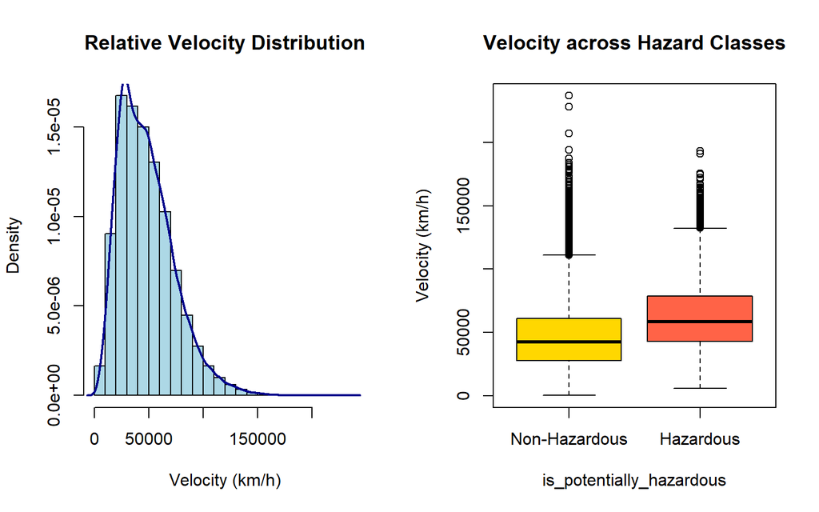

```r
par(mfrow = c(1, 2))

# Histogram with density curve
hist(neo_data$relative_velocity, breaks = 30, probability = TRUE, col = "lightblue",
     main = "Relative Velocity Distribution", xlab = "Velocity (km/h)")
lines(density(neo_data$relative_velocity), col = "darkblue", lwd = 2)

# Comparative Boxplot
boxplot(relative_velocity ~ is_potentially_hazardous, data = neo_data,
        col = c("gold", "tomato"), names = c("Non-Hazardous", "Hazardous"),
        main = "Velocity across Hazard Classes", ylab = "Velocity (km/h)")
```

```r
par(mfrow = c(1, 1))
```